# Final Assignment

Gonzalo de Quesada, email: gonzalo.dequesadaalzamora@helsinki.fi

12 de diciembre de 2017

## Research question

In this assignment we will explore the relations between maternal mortality and the expected years of schooling and adolescent birth rate. Our hypothesis is that the more adoscelent birth rate maternal mortality will increase because of the risks of pregnancy specially in younger women. Also how maternal mortality decrease with the years of schooling, this is assume because the more years of schooling could mean less adolescent pregnancy.

## Data

The dataset comes from the United Nations Development Programme. this dataset is the product of two different datasets used to calculate the human development index. for more information about the data you can visit the United Nations Development Programme [website](http://hdr.undp.org/en/content/human-development-index-hdi) and also check the [technical notes](http://hdr.undp.org/sites/default/files/hdr2015_technical_notes.pdf). you can also see the [data wrangling](https://github.com/gonzalodqa/IODS-final/blob/master/Data/create_human.R)

Lets inspect the structure of the dataset.it contains 177 observations and 6 variables.

```r
library(GGally)
library(dplyr)
library(corrplot)
library(ggplot2)
human <- read.csv("C:/Users/D E L L/Documents/GitHub/IODS-project/Data/human.csv", sep = ",", header = TRUE)
glimpse(human)
```

```
## Observations: 177
## Variables: 6
## $ yr.eduexp <dbl> 17.5, 20.2, 15.8, 18.7, 17.9, 16.5, 18.6, 16.5, 15.9...
## $ lifexp    <dbl> 81.6, 82.4, 83.0, 80.2, 81.6, 80.9, 80.9, 79.1, 82.0...
## $ GNI       <int> 64992, 42261, 56431, 44025, 45435, 43919, 39568, 529...
## $ matermor  <int> 4, 6, 6, 5, 6, 7, 9, 28, 11, 8, 6, 4, 8, 4, 27, 2, 1...
## $ adobirth  <dbl> 7.8, 12.1, 1.9, 5.1, 6.2, 3.8, 8.2, 31.0, 14.5, 25.3...
## $ repreparl <dbl> 39.6, 30.5, 28.5, 38.0, 36.9, 36.9, 19.9, 19.4, 28.2...
```

The variables in the dataset are:

yr.eduexp: Expected years of schooling

lifexp: Life expectancy at birth

GNI: Gross National Income per capita

matermor: Maternal mortality ratio

adobirth: Adolescent birth rate

repreparl: Percetange of female representatives in parliament

We now use the correlation matrix to see the relationship between the variables.

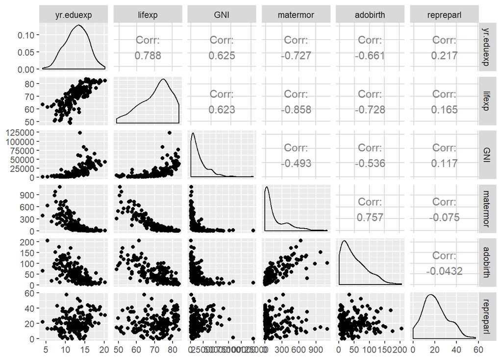

```r
ggpairs(human)
```

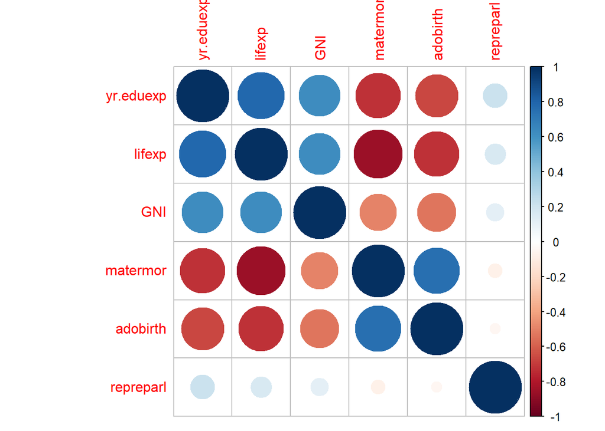

```r
cor(human) %>% corrplot
```

We can see a strong positive correlation between maternal mortality and adolescent birth rate, and also a strong negative correlation between maternal mortality and years of expected scholing

## Methods

We will use linear regression and k-means to analyse the data.

### Linear Regression

a linear regression analyse the relationship between a dependent variable y and one or more explanatory variables assuming the relashionship is linear.Linear regression can be expressed with the following formula:

y = Ax + B

Where A is the slope of the model and shows the relations in the model, and B is the point where the the model intersects the y axis. Linear regression assume that the errors are normally distributed, have constant variance and they do not depend on the explanatory variables

### K-means

K-means is a clustering method used to partition the input data set into k partitions (clusters) in which each observation belongs to the cluster with the nearest mean. To determine the optimal number of clusters we will use the cluster sum of squares.

## Results

### Linear Regression

We now fit our model using maternal mortality rate as the target variable and adolescent birth rate and years of expected education as the explanatory variables.

```r
model <- lm(matermor ~ yr.eduexp + adobirth, data = human)
summary(model)
```

```
##
## Call:
## lm(formula = matermor ~ yr.eduexp + adobirth, data = human)
##
## Residuals:
##     Min      1Q  Median      3Q     Max
## -232.89  -81.75  -15.89   49.27  681.33
##
## Coefficients:
##             Estimate Std. Error t value Pr(>|t|)
## (Intercept) 418.1982    66.9033   6.251 3.05e-09 ***
## yr.eduexp   -29.6675     4.3034  -6.894 9.60e-11 ***
## adobirth      2.5383     0.3032   8.371 1.82e-14 ***
## ---
## Signif. codes:  0 '***' 0.001 '**' 0.01 '*' 0.05 '.' 0.1 ' ' 1
##
## Residual standard error: 125.7 on 174 degrees of freedom
## Multiple R-squared:  0.6642, Adjusted R-squared:  0.6604
## F-statistic: 172.1 on 2 and 174 DF,  p-value: < 2.2e-16
```

```r
model
```

```
##
## Call:
## lm(formula = matermor ~ yr.eduexp + adobirth, data = human)
##
## Coefficients:
## (Intercept)    yr.eduexp     adobirth
##     418.198      -29.667        2.538
```

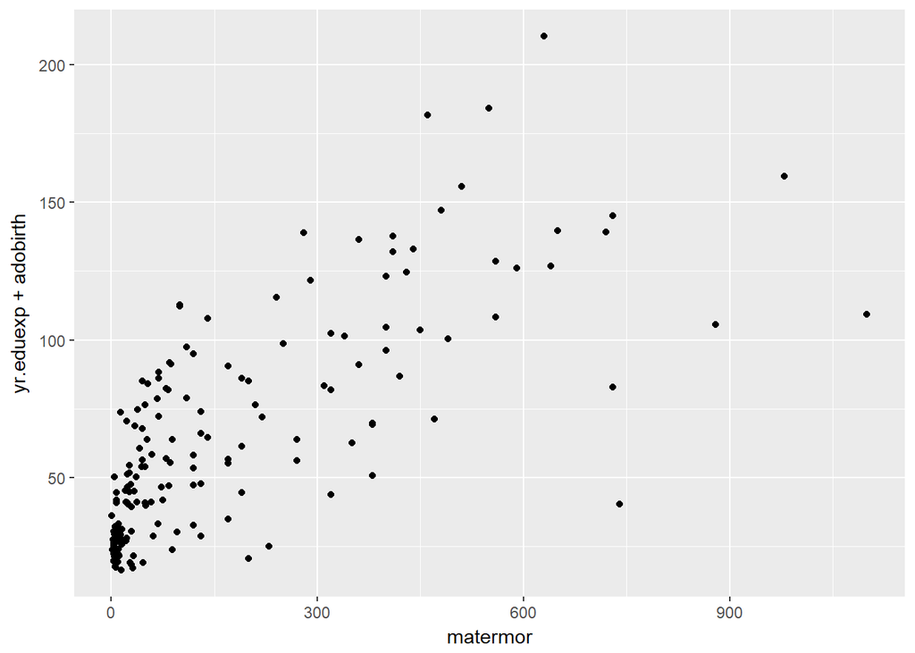

```r
g1 <- ggplot(human, aes(x=matermor, y=yr.eduexp + adobirth))
g1 + geom_point()
```

The p-value is very low confirming that there is relationship between variables. The multiple R squared value shows that 66.4% of the variability can be explained by the model.

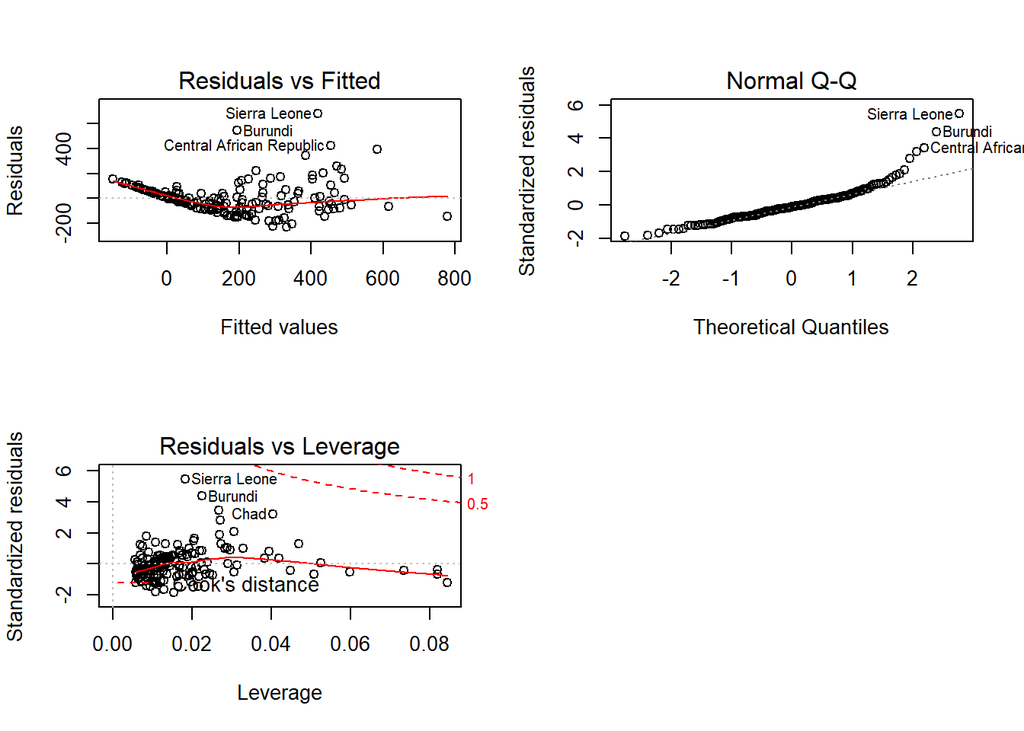

```r
par(mfrow = c(2,2))
plot(model, which= c(1,2,5))
```

### K-means

First we scaled our data so all the variables have a mean of 0 and calculate the euclidean distances.

```r
human_scaled <- scale(human)
summary(human_scaled)
```

```
##    yr.eduexp            lifexp             GNI             matermor
##  Min.   :-2.98002   Min.   :-2.5755   Min.   :-0.8679   Min.   :-0.7529
##  1st Qu.:-0.62892   1st Qu.:-0.7086   1st Qu.:-0.7085   1st Qu.:-0.6927
##  Median : 0.08663   Median : 0.2603   Median :-0.3189   Median :-0.4470
##  Mean   : 0.00000   Mean   : 0.0000   Mean   : 0.0000   Mean   : 0.0000
##  3rd Qu.: 0.76811   3rd Qu.: 0.7093   3rd Qu.: 0.3449   3rd Qu.: 0.3547
##  Max.   : 2.50587   Max.   : 1.5010   Max.   : 5.9808   Max.   : 4.3404
##     adobirth         repreparl
##  Min.   :-1.1808   Min.   :-1.78445
##  1st Qu.:-0.8327   1st Qu.:-0.70003
##  Median :-0.2348   Median :-0.09659
##  Mean   : 0.0000   Mean   : 0.00000
##  3rd Qu.: 0.5647   3rd Qu.: 0.58554
##  Max.   : 3.7218   Max.   : 3.24414
```

```r
dist_eu <- dist(human_scaled)
summary(dist_eu)
```

```
##    Min. 1st Qu.  Median    Mean 3rd Qu.    Max.
##  0.2533  1.9099  2.8761  3.1081  4.0551  9.7043
```

Then we find out what is the optimal amount of clusters, which accordinf to the plot seems to be 2.

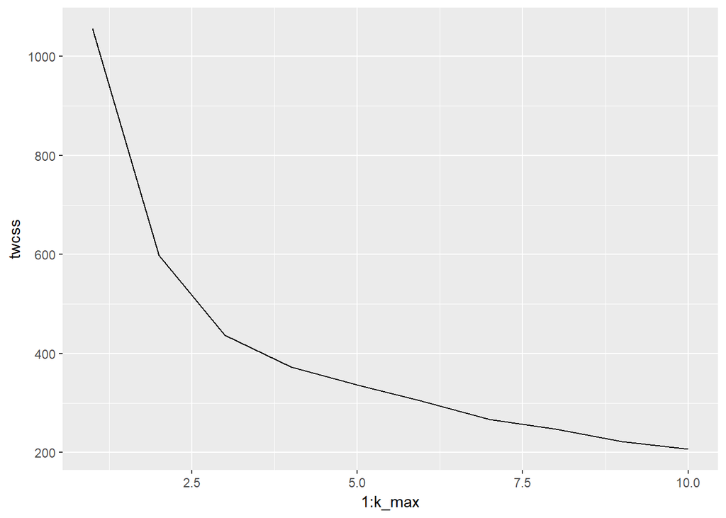

```r
k_max <- 10
twcss <- sapply(1:k_max, function(k){kmeans (human_scaled, k)$tot.withinss})
qplot(x = 1:k_max, y = twcss, geom = 'line')
```

Finally, we plot the clusters. It seems that the countries with higher maternal mortality have less years of expected education and also the countries with higher maternal mortality are the ones with more adolescent birth rates.

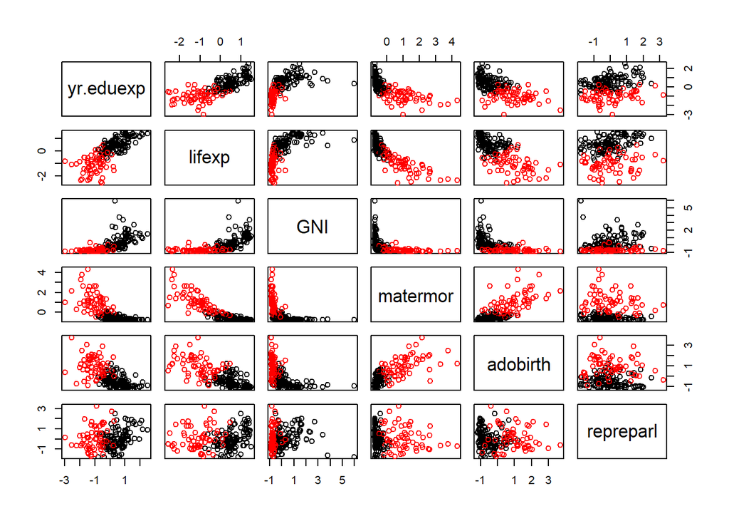

```r
km <-kmeans(human_scaled, centers = 2)
pairs(human_scaled,col = km$cluster)
```

## Conclusions

Even though the model explains a positive correlation between maternal mortality and adolescent birth rate, and a strong negative correlation between maternal mortality and years of expected education. And even though we had a strong multiple R squared value, we can not assure that the relation is linear because the validation process suggests that the assumptions made are not reasonable enough.